# ESS330: Lab 8 - Hyperparameter Tuning QMD

## **Final Model Verification**

```r
# 1. Last Fit

final_rf8_fit <- last_fit(
  final_rf8_wf, split = cam8_split,
  metrics = my_metrics)


# 2. Collecting metrics AGAIN

final_rf8_metfit <- collect_metrics(
  final_rf8_fit)

print(final_rf8_metfit)
```

```
# A tibble: 3 × 4
  .metric .estimator .estimate .config
  <chr>   <chr>          <dbl> <chr>
1 mae     standard       0.340 Preprocessor1_Model1
2 rmse    standard       0.627 Preprocessor1_Model1
3 rsq     standard       0.729 Preprocessor1_Model1
```

##### What we can understand from these results is that the final model performance with the test data is most telling in the relationship between MAE and RMSE. While RMSE is higher than MAE, it can tell us that most predictions are close to the actual observed values, but ther are some larger errors brining RMSE’s value closer 1 than 0. The Rsq value is also not too alarming, especially for envrionmental data whcih is incredibly variable in variance, 73% of this data falling within the predicted values, is a good value.

```r
# 3. Collecting Predictions

final8_pred <- collect_predictions(
  final_rf8_fit)

head(final8_pred)
```

```
# A tibble: 6 × 5
  .pred id                .row logQmean .config
  <dbl> <chr>            <int>    <dbl> <chr>
1 0.581 train/test split     5    0.781 Preprocessor1_Model1
2 0.776 train/test split     6    0.878 Preprocessor1_Model1
3 1.00  train/test split     7    1.00  Preprocessor1_Model1
4 0.703 train/test split    11    0.563 Preprocessor1_Model1
5 0.747 train/test split    14    0.552 Preprocessor1_Model1
6 0.563 train/test split    19    0.544 Preprocessor1_Model1
```

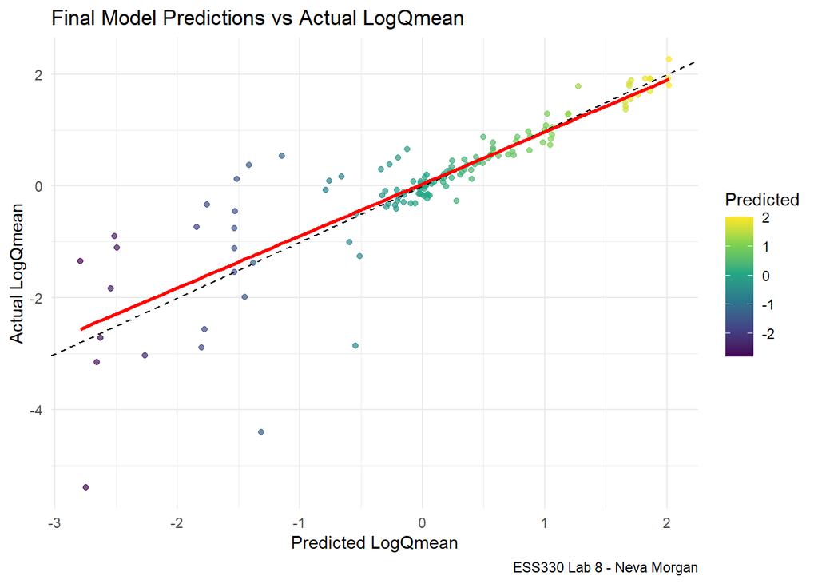

```r
# 4. PLOTTING TIME :)

ggplot(final8_pred, aes(x = .pred, y = logQmean)) +
  geom_point(aes(color = .pred), alpha = 0.7) +
  geom_abline(slope = 1, intercept = 0, linetype = "dashed", color = "black") +
  geom_smooth(method = "lm", se = FALSE, color = "red") +
  scale_color_viridis_c() +
  theme_minimal() +
  labs(
    title = "Final Model Predictions vs Actual LogQmean",
    caption = "ESS330 Lab 8 - Neva Morgan",
    x = "Predicted LogQmean",
    y = "Actual LogQmean",
    color = "Predicted"
  )
```

## **Building a Map!**

```r
# Fit the final model to ALL DATA

final_rf8_full <- final_rf8_wf %>%
  fit(data = camels_8)


# 1. Predict with augment()
camels_8_aug <- camels_8 %>%
  select(gauge_id, aridity, p_mean, logQmean)

camels8_preds <- augment(
  final_rf8_full,
  new_data = camels_8_aug)


# 3. Residuals with mutate()

camels8_preds <- camels8_preds %>%
  mutate(
    resid = (logQmean -
               .pred)^2)


# 4. Building Prediction and Residual Maps

camels8_coords <- read_delim("data/camels_topo.txt", show_col_types = FALSE) %>%
  select(gauge_id, gauge_lat, gauge_lon)

camels8_preds <- camels8_preds %>%
  left_join(camels8_coords, by = "gauge_id")

glimpse(camels8_preds)
```

```
Rows: 671
Columns: 8
$ .pred     <dbl> 0.5665945, 0.7280348, 0.6158056, 0.7132669, 0.6222160, 0.812…
$ gauge_id  <chr> "01013500", "01022500", "01030500", "01031500", "01047000", …
$ aridity   <dbl> 0.6305587, 0.5873564, 0.6241114, 0.5879503, 0.6289293, 0.561…
$ p_mean    <dbl> 3.126679, 3.608126, 3.274405, 3.522957, 3.323146, 3.730858, …
$ logQmean  <dbl> 0.5301308, 0.7761373, 0.5988956, 0.7081551, 0.7806403, 0.877…
$ resid     <dbl> 1.329604e-03, 2.313853e-03, 2.859469e-04, 2.613020e-05, 2.50…
$ gauge_lat <dbl> 47.23739, 44.60797, 45.50097, 45.17501, 44.86920, 44.87739, …
$ gauge_lon <dbl> -68.58264, -67.93524, -68.30596, -69.31470, -69.95510, -71.0…
```

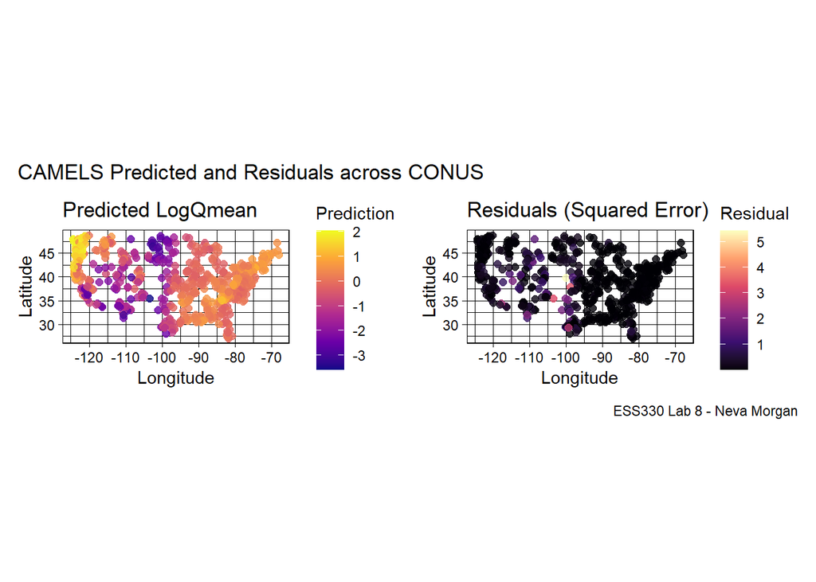

```r
#Prediction:
pred8_map <- ggplot(camels8_preds, aes(x = gauge_lon, y = gauge_lat)) +
  geom_point(aes(color = .pred), size = 2, alpha = 0.8) +
  scale_color_viridis_c(option = "C") +
  coord_fixed(1.3) +
  theme_linedraw() +
  labs(title = "Predicted LogQmean", x = "Longitude", y = "Latitude", color = "Prediction")

#Residual:
resid8_map <- ggplot(camels8_preds, aes(x = gauge_lon, y = gauge_lat)) +
  geom_point(aes(color = resid), size = 2, alpha = 0.8) +
  scale_color_viridis_c(option = "A") +
  coord_fixed(1.3) +
  theme_linedraw() +
  labs(title = "Residuals (Squared Error)", x = "Longitude", y = "Latitude", color = "Residual")


# 6. PATCHWORK COMBINING
library(patchwork)

pred8_map + resid8_map +
  plot_annotation(
    title = "CAMELS Predicted and Residuals across CONUS",
    caption = "ESS330 Lab 8 - Neva Morgan"
  )
```